# BUSA2002 Ass2 – Macro & Construction Dashboard Snapshot

NPT

23 October 2025

# 1 Executive Summary

Key points:

- GDP growth slowed in 2023 but remained positive into 2025.
- Inflation peaked in 2022 and eased through 2024–2025 while services disinflation lagged.
- Residential approvals weakened, while engineering workloads were supported by committed public projects.
- Public share of construction rose from ~23% (2020) to ~29% (2024).

# 2 Introduction

This report presents an overview of Australia’s macroeconomic and construction industry trends over the last 5 years, followed by recommendations for the next three years. Our focus is on how construction has contributed to the broader economy and explore the emerging opportunities ahead. The analysis draws on key indicators including GDP growth, inflation, the relationship between dwelling values and rents, total construction activity, sector trends (building vs engineering), the balance between public and private sector work, and industry turnover.

# 3 Data and Methods

We compile ABS and RBA series (2020–2025) for macro indicators and construction statistics. Plots referenced here are the same series presented in the Shiny dashboard and can be regenerated with the helper functions used in the app code.

```r
# Load the same helpers used by the dashboard and prepare data
helper_path <- if (file.exists("busa_helpers.R")) "busa_helpers.R" else "../busa_helpers.R"
source(helper_path)
# Make data path robust whether Rmd lives beside a local data/ or uses parent data/
data_dir <- if (dir.exists("data")) "data" else "../data"
macro_df <- load_macro_indicators(data_dir)
gdp_contrib <- load_gdp_contributions(data_dir)
gdp_growth <- load_gdp_growth(data_dir)
cpi_long <- load_cpi_goods_services(data_dir)
dw_rents <- load_dwelling_vs_rents(data_dir)
cwd_fy <- load_cwd_fy(data_dir)
cwd <- load_cwd_quarterlies(data_dir)
turnover_df <- load_turnover_indicator(data_dir)
```

# 4 Macroeconomic Performance (2020–2025)

## 4.1 Real GDP Growth

Household consumption and business spending drove the initial recovery in 2021 as mobility normalised and policy support such as JobKeeper preserved jobs. However, as interest rates rose from late 2022 onward, private demand slowed. Public demand helped stabilise activity through infrastructure programs. Education, travel, and commodities exports supported growth from late 2023 following reopening. The data indicates the 2023–2025 period saw slower but stable growth with normalising domestic demand.

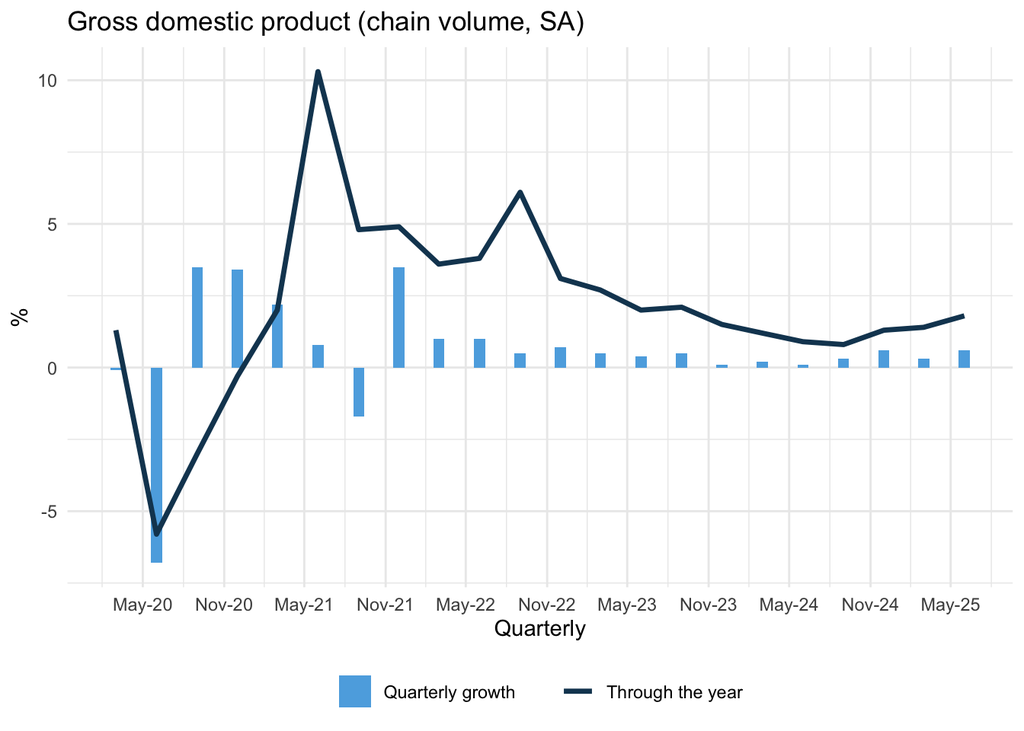

```r
df <- gdp_growth %>% filter(!is.na(date), date >= as.Date("2020-01-01"))
ggplot(df, aes(x = date)) +
  geom_col(aes(y = qoq_pct, fill = "Quarterly growth"), width = 25) +
  geom_line(aes(y = tty_pct, color = "Through the year"), linewidth = 1.2) +
  scale_fill_manual(values = c("Quarterly growth" = "#5DADE2"), name = NULL) +
  scale_color_manual(values = c("Through the year" = "#154360"), name = NULL) +
  labs(title = "Gross domestic product (chain volume, SA)", x = "Quarterly", y = "%") +
  theme_minimal() + theme(legend.position = "bottom") +
  scale_x_date(date_breaks = "6 months", date_labels = "%b-%y")
```

## 4.2 Contributions to Growth

Private demand led the early recovery. As rates rose from late 2022, private activity slowed, while public investment and net trade steadied growth. Construction cushioned the economy by transmitting policy and sustaining investment: public work offset the private slowdown, and engineering programs expanded productive capacity.

The sector’s training focus helps convert vacancies into capability, supporting the infrastructure pipeline while keeping hiring aligned to demand. A $1 million spend in construction generates roughly $2.9–3.0 million in activity and around nine jobs. The industry employs about 1.3 million people and pays roughly $66 billion in annual wages.

Higher borrowing costs reduced serviceability, pulling forward housing demand in 2021 and damping new dwelling and non-residential starts thereafter. Future momentum will depend on approvals and planning reform; housing policy will determine how quickly new supply eases affordability pressures.

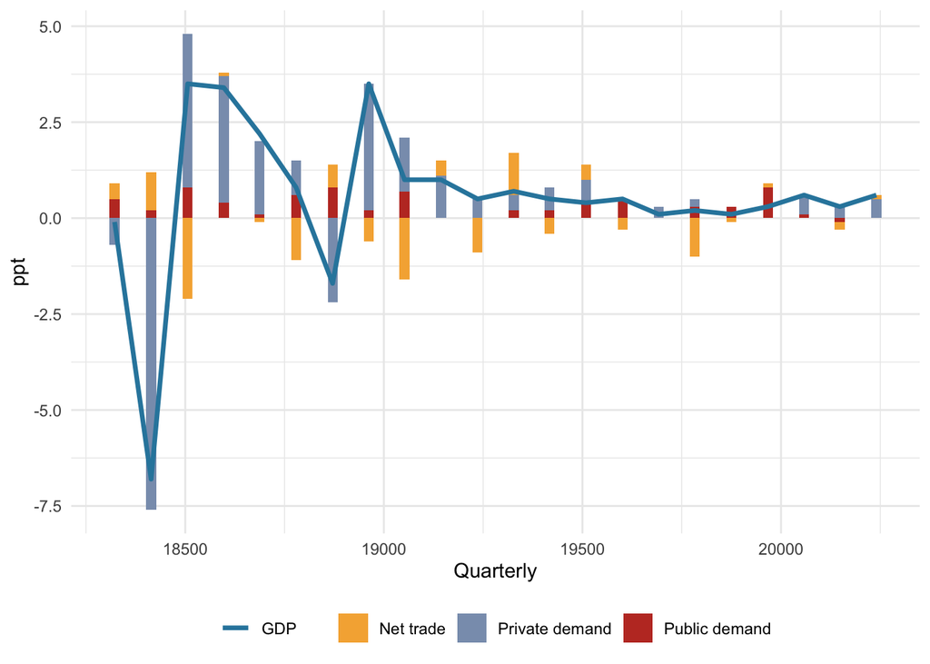

```r
df <- gdp_contrib %>% filter(!is.na(date), date >= as.Date("2020-01-01"))
df_long <- df %>%
  tidyr::pivot_longer(cols = c(private_demand, net_trade, public_demand),
                      names_to = "component", values_to = "ppt") %>%
  mutate(component = dplyr::recode(component,
                                   private_demand = "Private demand",
                                   net_trade = "Net trade",
                                   public_demand = "Public demand"))
ggplot() +
  geom_col(data = df_long, aes(x = date, y = ppt, fill = component), width = 25) +
  geom_line(data = df, aes(x = date, y = gdp_ppt, color = "GDP"), linewidth = 1.2) +
  scale_fill_manual(values = c("Private demand" = "#899DBA",
                               "Net trade" = "#F5B041",
                               "Public demand" = "#C0392B"), name = NULL) +
  scale_color_manual(values = c("GDP" = "#2E86AB"), name = NULL) +
  labs(x = "Quarterly", y = "ppt") +
  theme_minimal() + theme(legend.position = "bottom")
```

## 4.3 Inflation

[figure not shown]

```r
df <- macro_df %>% dplyr::filter(!is.na(date), date >= as.Date("2020-01-01")) %>%
  dplyr::select(date, cpi_inflation, cash_rate) %>%
  tidyr::pivot_longer(-date, names_to = "series", values_to = "value") %>%
  dplyr::mutate(series = dplyr::recode(series,
                                       cpi_inflation = "CPI Inflation",
                                       cash_rate = "Cash Rate"))
ggplot(df, aes(date, value, color = series)) +
  geom_line(linewidth = 1) +
  scale_color_manual(values = c("CPI Inflation" = "#f46d43", "Cash Rate" = "#1a9850"),
                     breaks = c("CPI Inflation","Cash Rate"), name = NULL) +
  scale_y_continuous(labels = scales::label_number(accuracy = 0.1)) +
  labs(x = "Year", y = "%") +
  theme_minimal() + theme(legend.position = "bottom")
```

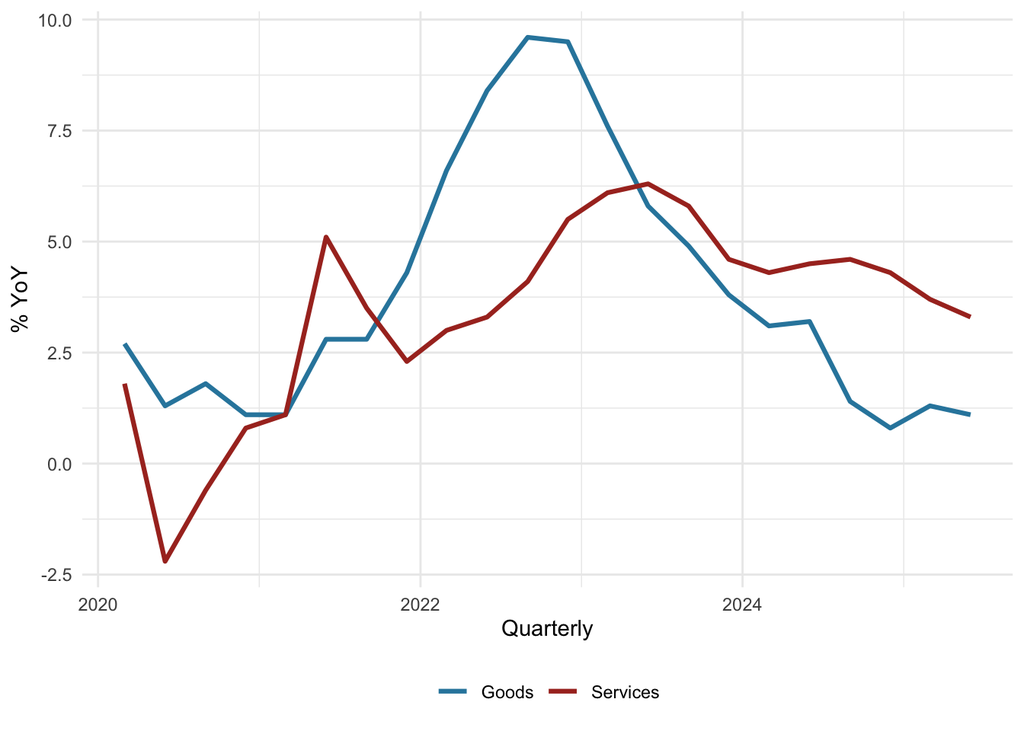

```r
df <- cpi_long %>% filter(!is.na(date), date >= as.Date("2020-01-01"))
ggplot(df, aes(date, yoy_pct, color = component)) +
  geom_line(linewidth = 1.1) +
  scale_y_continuous(labels = label_number(accuracy = 0.1)) +
  scale_color_manual(values = c("Goods" = "#2E86AB", "Services" = "#A93226"), name = NULL) +
  labs(x = "Quarterly", y = "% YoY") +
  theme_minimal() + theme(legend.position = "bottom")
```

Goods inflation fell back to normal levels quickly as supply bottlenecks eased. In contrast, services inflation has cooled more slowly, reflecting higher wage, rent, and insurance costs. The RBA and OECD expect inflation to return to the 2%–3% target range by 2025. However, ongoing rent increases could lift inflation further. If policy is loosened too early, services inflation may rise again, but keeping policy too tight could unnecessarily hold back interest-sensitive sectors.

- Higher borrowing costs: Increased interest rates raised the cost of housing and business capital expenditure.
- Income: Household consumption was reduced through lower disposable income.
- Exchange rate advantage: Imported materials and equipment were cheaper due to a stronger Australian dollar relative to the US dollar.
- Inflation expectations: Expectations and fears by businesses and employees were anchored through clear and credible monetary policy.

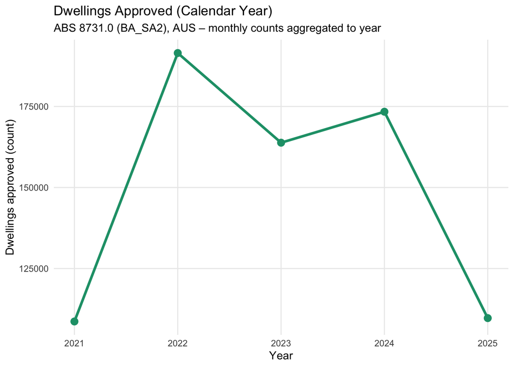

```r
ba_cy <- read.csv("../data/building_approvals_calendar_year.csv")
ggplot(ba_cy, aes(x = year, y = dwellings_approved)) +
  geom_line(linewidth = 1.2, color = "#1B9E77") +
  geom_point(size = 3, color = "#1B9E77") +
  labs(
    title = "Dwellings Approved (Calendar Year)",
    subtitle = "ABS 8731.0 (BA_SA2), AUS – monthly counts aggregated to year",
    x = "Year", y = "Dwellings approved (count)"
  ) +
  theme_minimal() + theme(panel.grid.minor = element_blank(), legend.position = "none")
```

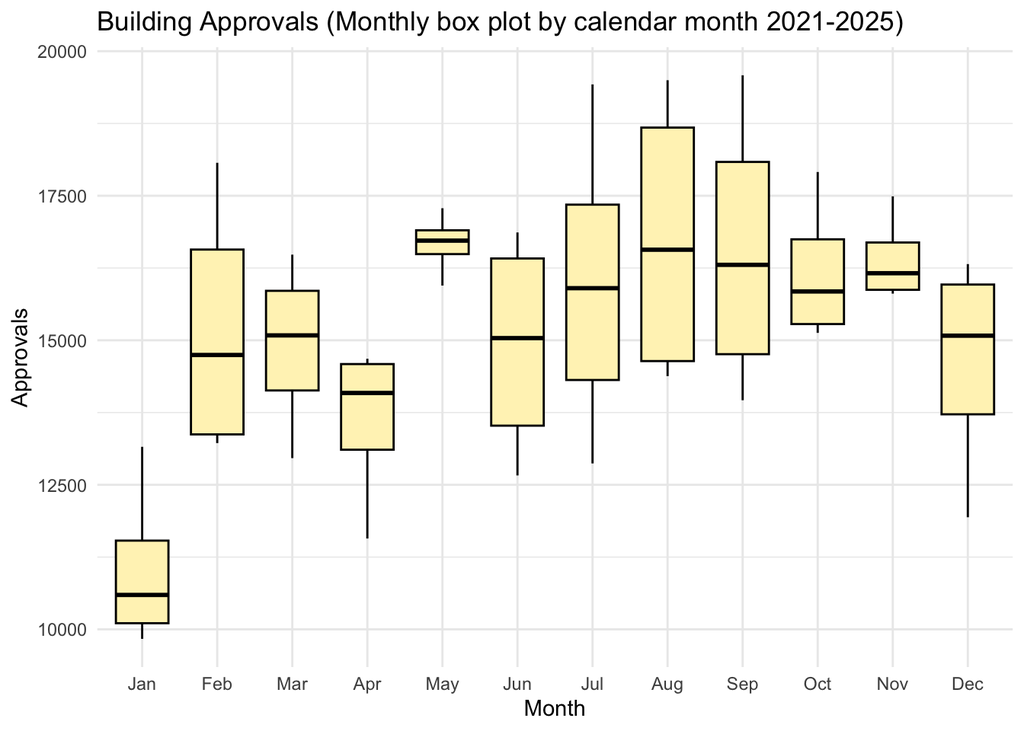

```r
# Building Approvals (Monthly box plot by calendar month 2021–2025)
approvals_m <- load_building_approvals_monthly(data_dir) %>%
  dplyr::mutate(year = lubridate::year(date)) %>%
  dplyr::filter(year >= 2021, year <= 2025) %>%
  dplyr::mutate(month_lab = factor(lubridate::month(date, label = TRUE, abbr = TRUE), levels = month.abb))
ggplot(approvals_m, aes(x = month_lab, y = approvals)) +
  geom_boxplot(outlier.alpha = 0.5, width = 0.7, fill = "#FFF3BF", color = "#000000") +
  labs(title = "Building Approvals (Monthly box plot by calendar month 2021-2025)", x = "Month", y = "Approvals") +
  theme_minimal()
```

## 4.4 Dwelling Value vs Rents

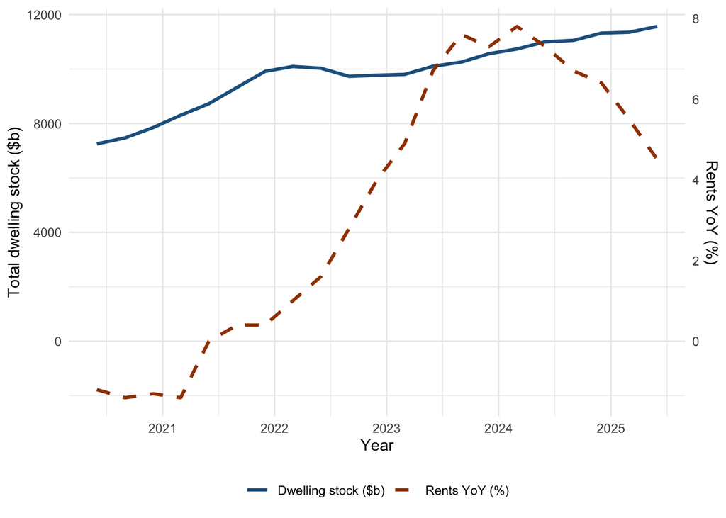

```r
dw <- dw_rents$dw %>% dplyr::filter(date >= as.Date("2020-01-01"))
rt <- dw_rents$rents %>% dplyr::filter(date >= as.Date("2020-01-01"))
merged <- dplyr::left_join(dw, rt, by = "date")
max_left <- max(merged$dw_value_b, na.rm = TRUE)
max_right <- max(merged$yoy_pct, na.rm = TRUE)
scale_factor <- ifelse(is.finite(max_left / max_right), max_left / max_right, 1)
ggplot(merged, aes(date)) +
  geom_line(aes(y = dw_value_b, color = "Dwelling stock ($b)"), linewidth = 1.1) +
  geom_line(aes(y = yoy_pct * scale_factor, color = "Rents YoY (%)"), linewidth = 1.1, linetype = "dashed") +
  scale_y_continuous(name = "Total dwelling stock ($b)",
                     sec.axis = sec_axis(~ ./scale_factor, name = "Rents YoY (%)")) +
  scale_color_manual(values = c("Dwelling stock ($b)" = "#1F618D",
                               "Rents YoY (%)" = "#A04000"), name = NULL) +
  labs(x = "Year") + theme_minimal() + theme(legend.position = "bottom")
```

# 5 Construction Industry Performance

## 5.1 Total Construction (FY)

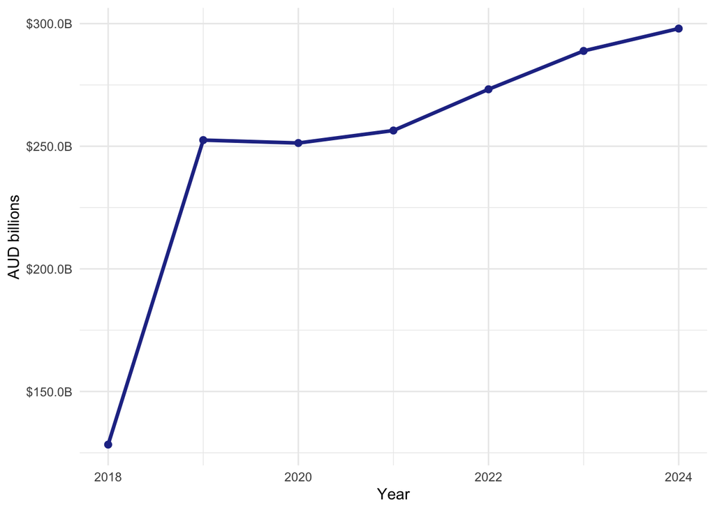

```r
df <- cwd_fy
ggplot(df, aes(year, total_b)) +
  geom_line(linewidth = 1.2, color = "#253494") +
  geom_point(size = 2, color = "#253494") +
  scale_y_continuous(labels = label_dollar(prefix = "$", suffix = "B", accuracy = 0.1)) +
  labs(x = "Year", y = "AUD billions") + theme_minimal()
```

## 5.2 Building vs Engineering (FY)

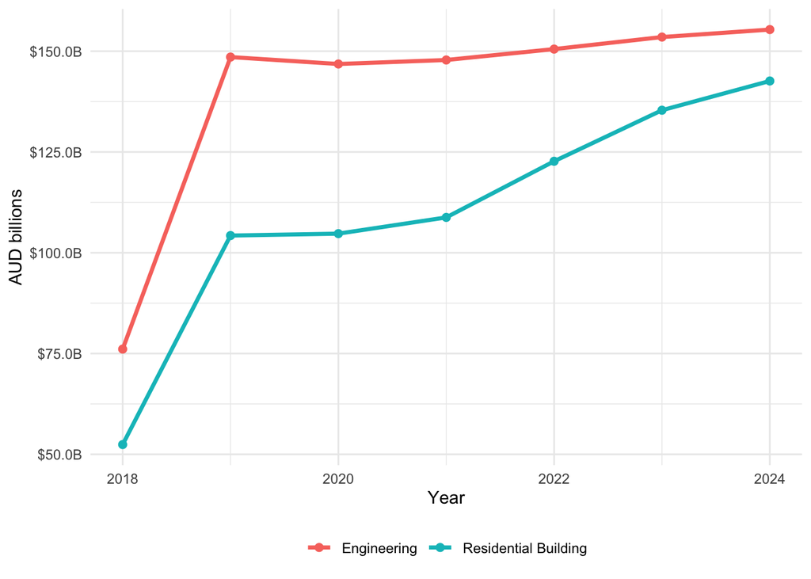

```r
df <- cwd_fy %>% select(year, building_b, engineering_b) %>%
  tidyr::pivot_longer(-year, names_to = "sector", values_to = "value_b") %>%
  mutate(sector = dplyr::recode(sector, building_b = "Residential Building", engineering_b = "Engineering"))
ggplot(df, aes(year, value_b, color = sector)) +
  geom_line(linewidth = 1.2) + geom_point(size = 2) +
  scale_y_continuous(labels = label_dollar(prefix = "$", suffix = "B", accuracy = 0.1)) +
  labs(x = "Year", y = "AUD billions", color = NULL) +
  theme_minimal() + theme(legend.position = "bottom")
```

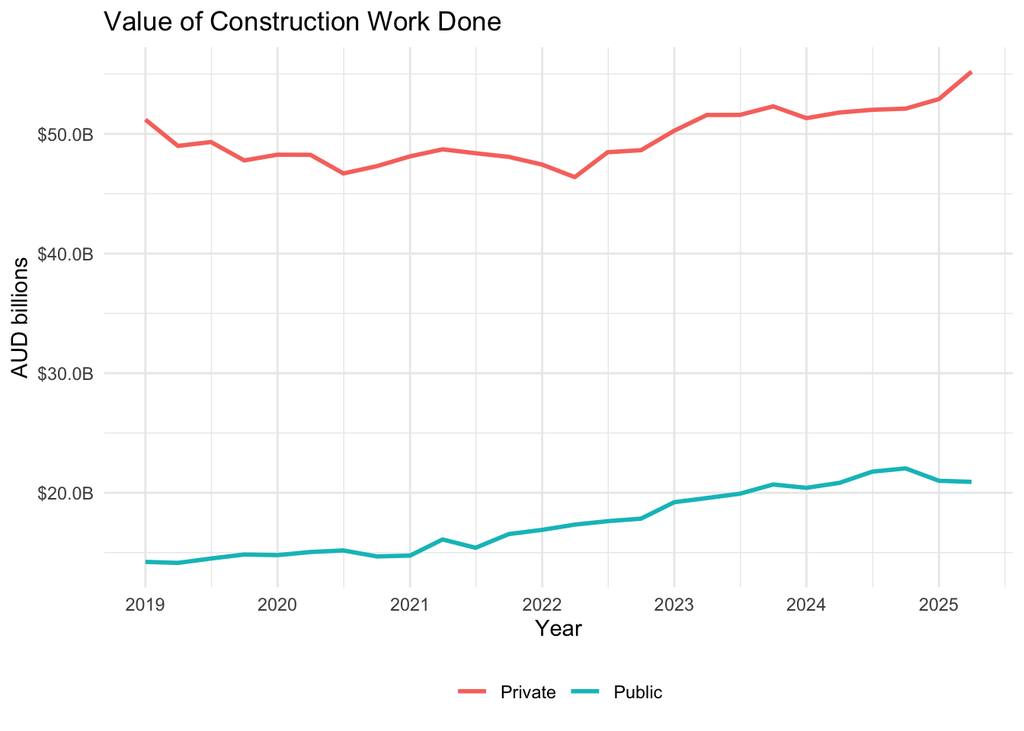

```r
# Match dashboard Public vs Private Work Done (CVM) – quarterly
pub_priv_q <- load_pub_priv_quarterly(data_dir)
df_q <- pub_priv_q %>%
  dplyr::select(date, public_m, private_m) %>%
  tidyr::pivot_longer(-date, names_to = "owner", values_to = "value_m") %>%
  dplyr::mutate(owner = dplyr::recode(owner, private_m = "Private", public_m = "Public"),
                value_b = value_m / 1000)
ggplot(df_q, aes(date, value_b, color = owner)) +
  geom_line(linewidth = 1) +
  scale_y_continuous(labels = scales::label_dollar(prefix = "$", suffix = "B", accuracy = 0.1)) +
  labs(title = "Value of Construction Work Done", x = "Year", y = "AUD billions", color = NULL) +
  theme_minimal() + theme(legend.position = "bottom") +
  scale_x_date(date_breaks = "1 year", date_labels = "%Y")
```

## 5.3 Public vs Private

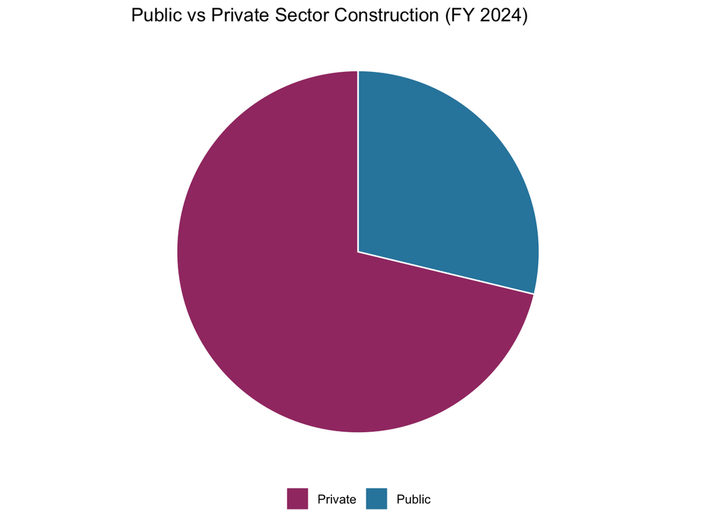

```r
# FY composition for the latest FY in range (match dashboard pie)
yr_sel <- max(cwd_fy$year, na.rm = TRUE)
latest <- dplyr::filter(cwd_fy, year == yr_sel)
if (nrow(latest) > 0) {
  vals <- c(as.numeric(latest$public_share), as.numeric(100 - latest$public_share))
  labs <- c("Public", "Private")
  df_pie <- tibble::tibble(label = labs, share = vals)
  ggplot(df_pie, aes(x = 1, y = share, fill = label)) +
    geom_col(width = 1, color = "white") +
    coord_polar(theta = "y") +
    scale_fill_manual(values = c("Public" = "#2E86AB", "Private" = "#A23B72"), name = NULL) +
    labs(title = paste0("Public vs Private Sector Construction (FY ", yr_sel, ")"), x = NULL, y = NULL) +
    theme_void() + theme(legend.position = "bottom")
}
```

Larger contractors benefit most, as they are better equipped for large, multi-year, complex projects. Smaller firms may struggle to compete due to limited specialist manpower and often face stricter compliance requirements than in residential or commercial work.

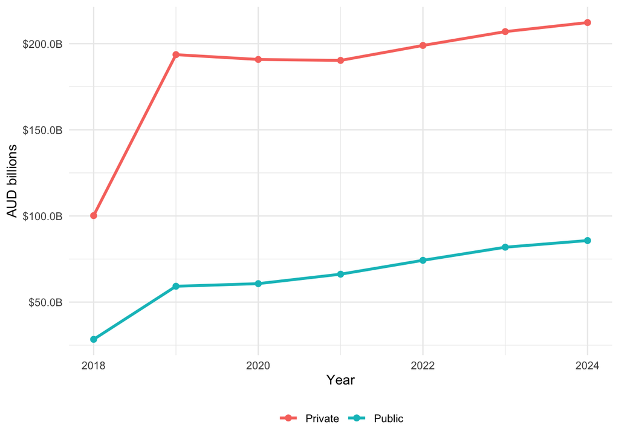

```r
df <- cwd_fy %>% select(year, public_b, private_b) %>%
  tidyr::pivot_longer(-year, names_to = "owner", values_to = "value_b") %>%
  mutate(owner = dplyr::recode(owner, private_b = "Private", public_b = "Public"))
ggplot(df, aes(year, value_b, color = owner)) +
  geom_line(linewidth = 1.1) + geom_point(size = 2) +
  scale_y_continuous(labels = label_dollar(prefix = "$", suffix = "B", accuracy = 0.1)) +
  labs(x = "Year", y = "AUD billions", color = NULL) + theme_minimal() +
  theme(legend.position = "bottom")
```

## 5.4 Turnover

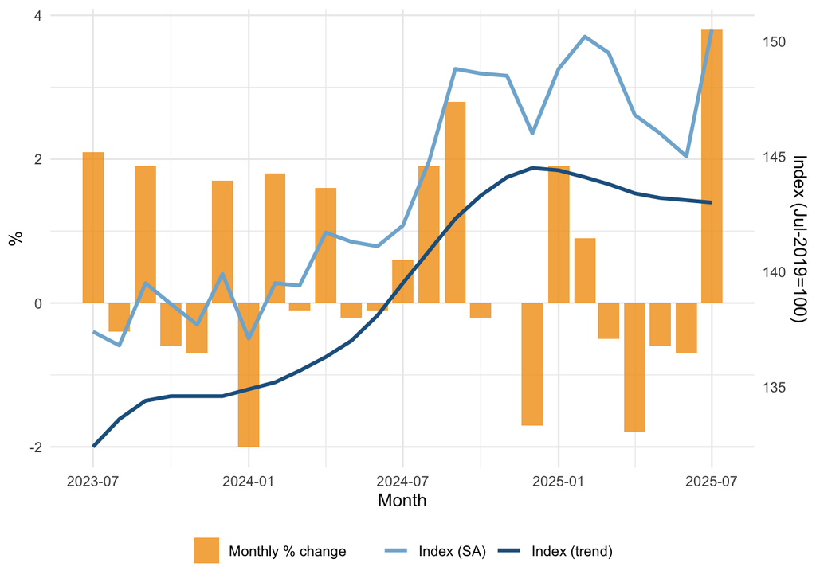

```r
df <- turnover_df
min_pct <- min(df$pct_change_sa, na.rm = TRUE); max_pct <- max(df$pct_change_sa, na.rm = TRUE)
min_idx <- min(c(df$idx_sa, df$idx_trend), na.rm = TRUE); max_idx <- max(c(df$idx_sa, df$idx_trend), na.rm = TRUE)
k <- (max_idx - min_idx) / (max_pct - min_pct + 1e-9)
df <- df %>% mutate(idx_sa_scaled = (idx_sa - min_idx)/k + min_pct,
                    idx_tr_scaled = (idx_trend - min_idx)/k + min_pct)
ggplot(df, aes(x = date)) +
  geom_col(aes(y = pct_change_sa, fill = "Monthly % change"), width = 25, alpha = 0.8) +
  geom_line(aes(y = idx_sa_scaled, color = "Index (SA)"), linewidth = 1.1) +
  geom_line(aes(y = idx_tr_scaled, color = "Index (trend)"), linewidth = 1.1) +
  scale_y_continuous(name = "%", sec.axis = sec_axis(~ (.-min_pct) * k + min_idx, name = "Index (Jul-2019=100)")) +
  scale_color_manual(values = c("Index (SA)" = "#7FB3D5", "Index (trend)" = "#1F618D"), name = NULL) +
  scale_fill_manual(values = c("Monthly % change" = "#F39C12"), name = NULL) +
  labs(x = "Month") + theme_minimal() + theme(legend.position = "bottom")
```

# 6 Opportunities (Next Three Years)

Engineering presents the clearest growth pathway, supported by the national infrastructure pipeline and energy transmission upgrades. Non residential offers selective opportunities (health, education, advanced manufacturing), while residential remains interest sensitive but could benefit from targeted housing policy. We recommend the Western Sydney Airport Metro project.

**Overview**

A new metro line connecting St Marys to Western Sydney Airport and the Aerotropolis. This project aims to improve transport to the airport and support the development of the surrounding area.

- **Value:** $11 billion, jointly funded by the Commonwealth and NSW Government
- **Scope:** 23 km of new metro line with six stations
- **Status:** Under construction; staged works to align with the airport opening

**Opportunities**

- **Rail Infrastructure:** Track laying, signalling, and electrification works
- **Station Construction:** Modern facilities with accessibility features
- **Bridge and Tunnel Works:** Grade separations and river crossings
- **Utilities Integration:** Power, water, and telecommunications infrastructure

# 7 Conclusion

Engineering construction is best placed to drive near term growth, with Western Sydney Airport Metro the preferred expansion opportunity. Public investment, energy transition projects, and normalising inflation support the sector’s outlook, while residential activity will depend on approvals and affordability.

# 8 Shiny Dashboard Code (full)

The dashboard code used for interactive exploration (Macro, GDP, Prices & Housing, Sector, Public vs Private, Labour & Turnover) is shown in full below from `app.R`.

```r
library(shiny)
library(dplyr)
library(readr)
library(tidyr)
library(ggplot2)
library(scales)
library(lubridate)
library(janitor)
library(zoo)
library(plotly)
source("busa_helpers.R")

# Declare NSE globals for dplyr/ggplot to satisfy linters
utils::globalVariables(c(
  "building_m", "engineering_m", "gdp_growth", "cpi_inflation", "cash_rate",
  "value", "series", "value_millions", "value_m", "sector", "public_m",
  "private_m", "owner", "public_share", "approvals", "industry", "aug_2024",
  "is_construction", "idx_sa", "idx_trend", "index", "time_period", "date",
  "year", "total_m", "reference_month", "component", "yoy_pct", "dw_value_b",
  "pct_change_sa", "idx_sa_scaled", "idx_tr_scaled", "aug_2019", "month_lab"
))

# --- Helpers ---
parse_quarter_date <- function(q) {
  # Convert strings like "2023-Q1" to Date at quarter start
  as.Date(zoo::as.yearqtr(gsub("-", " ", q)))
}

# Plotly utility: clean up legend names like "(GDP,1)" => "GDP"
fix_plotly_legend_names <- function(pl) {
  if (!is.null(pl$x$data)) {
    for (i in seq_along(pl$x$data)) {
      nm <- pl$x$data[[i]]$name
      if (!is.null(nm)) {
        nm2 <- gsub("[()]", "", nm)
        nm2 <- sub(",?1$", "", nm2)
        pl$x$data[[i]]$name <- nm2
      }
    }
  }
  # Ensure expected legend interactions: single-click toggles, double-click isolates
  pl <- plotly::layout(
    pl,
    legend = list(
      itemclick = "toggle",
      itemdoubleclick = "toggleothers",
      groupclick = "toggleitem"
    )
  )
  pl
}

to_plotly <- function(p, tooltip) {
  fix_plotly_legend_names(ggplotly(p, tooltip = tooltip))
}

data_dir <- "data"

# Load via helpers (mirroring ARBE transformations)
macro_df <- load_macro_indicators(data_dir) %>% mutate(year = year(date))
gdp_contrib <- load_gdp_contributions(data_dir)
gdp_growth <- load_gdp_growth(data_dir)
cpi_long <- load_cpi_goods_services(data_dir)
dw_rents <- load_dwelling_vs_rents(data_dir)
gva_df <- load_gva(data_dir)
cwd <- load_cwd_quarterlies(data_dir)
cwd_total_q <- cwd$total %>% mutate(year = year(date), value_millions = value_m / 1000)
cwd_building_q <- cwd$building %>% mutate(year = year(date)) %>% rename(building_m = value_m)
cwd_engineering_q <- cwd$engineering %>% mutate(year = year(date)) %>% rename(engineering_m = value_m)
cwd_pub_priv_q <- load_pub_priv_quarterly(data_dir) %>%
  mutate(year = year(date), total_m = public_m + private_m, public_share = public_m / pmax(total_m, 1e-9))
approvals_m <- load_building_approvals_monthly(data_dir) %>% mutate(year = year(date))
turnover_df <- load_turnover_indicator(data_dir) %>% mutate(year = year(date))
earnings_df <- load_earnings_industry(data_dir)
cwd_fy <- load_cwd_fy(data_dir)

# --- Ranges ---
safe_years <- c(
  if ("year" %in% names(cwd_total_q)) cwd_total_q$year,
  if ("year" %in% names(cwd_pub_priv_q)) cwd_pub_priv_q$year,
  if ("year" %in% names(approvals_m)) approvals_m$year,
  if ("year" %in% names(macro_df)) macro_df$year,
  if ("year" %in% names(turnover_df)) turnover_df$year
)
year_min <- min(safe_years, na.rm = TRUE)
year_max <- max(safe_years, na.rm = TRUE)

# --- UI ---
ui <- fluidPage(
  titlePanel("Dashboard"),
  tabsetPanel(
        tabPanel(
          "Info",
          div(style = "max-width:900px; margin:16px auto; line-height:1.6;",
              h3("How to use this dashboard"),
              tags$ul(
                tags$li("Hover over charts to see detailed tooltips (exact values)."),
                tags$li("Use the legend: click to toggle a series; double-click to isolate it."),
                tags$li("Filter all time-series with the Year Range slider at the bottom."),
                tags$li("Macro Overview → use the month filter to show a single month's bars across years."),
                tags$li("Use the toolbar on each chart (top-right) to zoom, pan or download PNGs.")
              ),
              hr(),
              tags$p("Explore the tabs above for Macro, GDP, Prices & Housing, Sector and more.")
          )
        ),
        tabPanel(
          "Macro Overview",
          div(style = "padding: 0 15px 6px;",
              selectInput(
                "macro_month_filter",
                label = "Filter bars by month (optional)",
                choices = c("All months", "January", "February", "March", "April"),
                selected = "All months",
                width = "260px"
              )
          ),
          plotly::plotlyOutput("macro_gdp", height = 260),
          plotly::plotlyOutput("macro_cpi_rate", height = 260)
        ),
        tabPanel(
          "GDP",
          plotly::plotlyOutput("gdp_contrib", height = 320),
          plotly::plotlyOutput("gdp_growth", height = 320)
        ),
        tabPanel(
          "Prices & Housing",
          plotly::plotlyOutput("cpi_goods_services", height = 280),
          plotly::plotlyOutput("dwelling_vs_rents", height = 300)
        ),
        tabPanel(
          "Sector Data",
          plotly::plotlyOutput("fy_total", height = 280),
          plotly::plotlyOutput("fy_sectors", height = 280),
          div(style = "margin-top: 22px;",
              plotly::plotlyOutput("fy_public_share", height = 260)
          )
        ),
        tabPanel(
          "Public vs Private",
          plotly::plotlyOutput("pub_priv_levels", height = 320),
          div(style = "padding: 0 15px;",
              checkboxInput("show_ci", "Show confidence interval", value = TRUE)
          ),
          plotly::plotlyOutput("pub_share", height = 320)
        ),
        tabPanel(
          "Approvals",
          plotly::plotlyOutput("approvals_trend", height = 320),
          plotly::plotlyOutput("approvals_yearly", height = 280),
          plotly::plotlyOutput("gva_annual", height = 320)
        ),
        tabPanel(
          "Labour & Turnover",
          tags$div(style = "text-align:left;", plotly::plotlyOutput("earnings_bar", height = 520, width = "100%")),
          plotly::plotlyOutput("turnover_trend", height = 360),
          plotly::plotlyOutput("vacancies_lines", height = 340)
        )
  ),
  br(),
  div(class = "well well-sm", style = "padding:8px 12px; margin:6px 12px;",
      div(style = "max-width:900px; margin:0 auto;",
          sliderInput(
            "year_range", "Year Range:",
            min = year_min, max = year_max, value = c(max(year_min, 2019), year_max), step = 1, sep = "", width = "100%"
          )
      )
  )
)
```

```r
# --- Server ---
server <- function(input, output, session) {
  # Reactive filters
  macro_re <- reactive({ macro_df %>% filter(year >= input$year_range[1], year <= input$year_range[2]) })
  cwd_total_re <- reactive({ cwd_total_q %>% filter(year >= input$year_range[1], year <= input$year_range[2]) })
  sectors_re <- reactive({
    left_join(cwd_building_q, cwd_engineering_q, by = c("time_period", "date", "year")) %>%
      filter(year >= input$year_range[1], year <= input$year_range[2]) %>%
      pivot_longer(c(building_m, engineering_m), names_to = "sector", values_to = "value_m")
  })
  pub_priv_re <- reactive({ cwd_pub_priv_q %>% filter(year >= input$year_range[1], year <= input$year_range[2]) })
  approvals_re <- reactive({ approvals_m %>% filter(year >= input$year_range[1], year <= input$year_range[2]) })
  approvals_yearly <- reactive({
    # Prefer pre-aggregated calendar-year totals to match original PNG
    path_cy <- file.path(data_dir, "building_approvals_calendar_year.csv")
    if (file.exists(path_cy)) {
      readr::read_csv(path_cy, show_col_types = FALSE) %>%
        janitor::clean_names() %>%
        filter(year >= input$year_range[1], year <= input$year_range[2])
    } else {
      # Fallback: aggregate monthly to calendar year
      path_m <- file.path(data_dir, "building_approvals_monthly.csv")
      if (file.exists(path_m)) {
        readr::read_csv(path_m, show_col_types = FALSE) %>%
          janitor::clean_names() %>%
          transmute(date = lubridate::ym(time_period), approvals = as.numeric(obs_value)) %>%
          mutate(year = lubridate::year(date)) %>%
          group_by(year) %>% summarise(dwellings_approved = sum(approvals, na.rm = TRUE), .groups = "drop") %>%
          filter(year >= input$year_range[1], year <= input$year_range[2])
      } else tibble::tibble()
    }
  })
  turnover_re <- reactive({ turnover_df %>% filter(year >= input$year_range[1], year <= input$year_range[2]) })

  # Macro plots
  output$gdp_contrib <- renderPlotly({
    df <- gdp_contrib %>% filter(!is.na(date), date >= as.Date("2020-01-01"))
    df_long <- df %>% pivot_longer(cols = c(private_demand, net_trade, public_demand), names_to = "component", values_to = "ppt") %>%
      mutate(component = recode(component,
        private_demand = "Private demand",
        net_trade = "Net trade",
        public_demand = "Public demand"
      ))
    p <- ggplot() +
      geom_col(data = df_long, aes(x = date, y = ppt, fill = component), width = 25) +
      geom_line(data = df, aes(x = date, y = gdp_ppt, color = "GDP"), linewidth = 1.2) +
      scale_fill_manual(values = c("Private demand" = "#899DBA", "Net trade" = "#F5B041", "Public demand" = "#C0392B")) +
      scale_color_manual(values = c("GDP" = "#2E86AB"), guide = "legend") +
      labs(title = "Contributions to quarterly growth in GDP",
           x = "Quarterly", y = "ppt", fill = NULL, color = NULL) +
      theme_minimal() + theme(legend.position = "bottom") +
      scale_x_date(date_breaks = "6 months", date_labels = "%b-%y")
    fix_plotly_legend_names(ggplotly(p, tooltip = c("x","y","fill","color")))
  })

  output$gdp_growth <- renderPlotly({
    df <- gdp_growth %>% filter(!is.na(date), date >= as.Date("2020-01-01"))
    p <- ggplot(df, aes(x = date)) +
      geom_col(aes(y = qoq_pct, fill = "Quarterly growth"), width = 25) +
      geom_line(aes(y = tty_pct, color = "Through the year"), linewidth = 1.2) +
      scale_fill_manual(values = c("Quarterly growth" = "#5DADE2")) +
      scale_color_manual(values = c("Through the year" = "#154360")) +
      labs(title = "Gross domestic product (chain volume, SA)", x = "Quarterly", y = "%", fill = NULL, color = NULL) +
      theme_minimal() + theme(legend.position = "bottom") +
      scale_x_date(date_breaks = "6 months", date_labels = "%b-%y")
    fix_plotly_legend_names(ggplotly(p, tooltip = c("x","y","fill","color")))
  })
  output$macro_gdp <- renderPlotly({
    df <- macro_re() %>%
      mutate(month_lab = factor(month(date, label = TRUE, abbr = TRUE), levels = month.abb),
             month_full = factor(month(date, label = TRUE, abbr = FALSE), levels = month.name))
    # Optional filter by month
    if (!is.null(input$macro_month_filter) && input$macro_month_filter != "All months") {
      df <- df %>% filter(month_full == input$macro_month_filter)
    }
    p <- ggplot(df, aes(date, gdp_growth, fill = month_lab)) +
      geom_col(width = 25) +
      geom_hline(yintercept = 0, linetype = "dashed", color = "grey50") +
      scale_fill_brewer(palette = "Set3", name = "Month") +
      scale_y_continuous(labels = label_number(accuracy = 0.1)) +
      scale_x_date(date_breaks = "1 year", date_labels = "%Y") +
      labs(title = "GDP growth (%)", x = "Year", y = "%") +
      theme_minimal() + theme(legend.position = "bottom")
    fix_plotly_legend_names(ggplotly(p, tooltip = c("x","y","fill")))
  })

  output$macro_cpi_rate <- renderPlotly({
    df <- macro_re() %>%
      select(date, cpi_inflation, cash_rate) %>%
      pivot_longer(-date, names_to = "series", values_to = "value") %>%
      mutate(series = recode(series,
                             cpi_inflation = "CPI Inflation",
                             cash_rate = "Cash Rate"))
    p <- ggplot(df, aes(date, value, color = series)) +
      geom_line(linewidth = 1) +
      scale_color_manual(values = c("CPI Inflation" = "#f46d43", "Cash Rate" = "#1a9850"),
                         breaks = c("CPI Inflation", "Cash Rate"), name = NULL) +
      scale_y_continuous(labels = label_number(accuracy = 0.1)) +
      labs(title = "Inflation and Cash Rate", x = "Year", y = "%") +
      theme_minimal() + theme(legend.position = "bottom")
    fix_plotly_legend_names(ggplotly(p, tooltip = c("x","y","series")))
  })

  # Construction FY (ARBE-style)
  output$fy_total <- renderPlotly({
    df <- cwd_fy
    p <- ggplot(df, aes(year, total_b)) +
      geom_line(linewidth = 1.2, color = "#253494") +
      geom_point(size = 2, color = "#253494") +
      scale_y_continuous(labels = label_dollar(prefix = "$", suffix = "B", accuracy = 0.1)) +
      scale_x_continuous(breaks = df$year) +
      labs(title = "Total Construction Work Done (FY, CVM SA)", x = "Year", y = "AUD billions") +
      theme_minimal()
    fix_plotly_legend_names(ggplotly(p, tooltip = c("x","y")))
  })
```

```r
  output$fy_sectors <- renderPlotly({
    df <- cwd_fy %>% select(year, building_b, engineering_b) %>% pivot_longer(-year, names_to = "sector", values_to = "value_b") %>%
      mutate(sector = recode(sector, building_b = "Residential Building", engineering_b = "Engineering"))
    p <- ggplot(df, aes(year, value_b, color = sector)) +
      geom_line(linewidth = 1.2) +
      geom_point(size = 2) +
      scale_y_continuous(labels = label_dollar(prefix = "$", suffix = "B", accuracy = 0.1)) +
      scale_x_continuous(breaks = cwd_fy$year) +
      labs(title = "Construction Sector Performance (FY, CVM SA)", x = "Year", y = "AUD billions", color = NULL) +
      theme_minimal() + theme(legend.position = "bottom")
    fix_plotly_legend_names(ggplotly(p, tooltip = c("x","y","sector")))
  })

  output$fy_public_share <- renderPlotly({
    # Show a pie for the most relevant FY within the selected range
    yr_sel <- min(max(cwd_fy$year, na.rm = TRUE), input$year_range[2])
    latest <- cwd_fy %>% filter(year == yr_sel)
    if (nrow(latest) == 0) return(NULL)
    vals <- c(as.numeric(latest$public_share), as.numeric(100 - latest$public_share))
    labs <- c("Public", "Private")
    plotly::plot_ly(
      labels = labs,
      values = vals,
      type = "pie",
      textinfo = "label+percent",
      insidetextorientation = "radial",
      marker = list(colors = c("#2E86AB", "#A23B72"))
    ) %>%
      plotly::layout(title = list(text = paste0("Public vs Private Sector Construction (FY ", yr_sel, ")")),
                     showlegend = TRUE)
  })

  # Public vs Private
  output$pub_priv_levels <- renderPlotly({
    df <- pub_priv_re() %>% select(date, public_m, private_m) %>% pivot_longer(-date, names_to = "owner", values_to = "value_m") %>%
      mutate(owner = recode(owner, private_m = "Private", public_m = "Public"),
             value_b = value_m / 1000)
    p <- ggplot(df, aes(date, value_b, color = owner)) +
      geom_line(linewidth = 1) +
      scale_y_continuous(labels = label_dollar(prefix = "$", suffix = "B", accuracy = 0.1)) +
      scale_color_manual(values = c("Private" = "#d95f02", "Public" = "#1b9e77"),
                         breaks = c("Private","Public"), name = NULL) +
      labs(title = "Value of Construction Work Done", x = "Year", y = "AUD billions") +
      theme_minimal() + theme(legend.position = "bottom") +
      scale_x_date(date_breaks = "1 year", date_labels = "%Y")
    fix_plotly_legend_names(ggplotly(p, tooltip = c("x","y","owner")))
  })

  output$pub_share <- renderPlotly({
    df <- pub_priv_re()
    p <- ggplot(df, aes(date, public_share)) +
      geom_point(color = "#1b9e77", size = 2, alpha = 0.6) +
      geom_smooth(method = "lm", se = input$show_ci, color = "#1b9e77", fill = "#1b9e77", alpha = 0.2) +
      scale_y_continuous(labels = percent_format(accuracy = 0.1)) +
      labs(title = "Public Share of Total Construction Work Done", x = "Year", y = "Share of total") +
      theme_minimal() +
      scale_x_date(date_breaks = "1 year", date_labels = "%Y")
    fix_plotly_legend_names(ggplotly(p, tooltip = c("x","y")))
  })

  # Approvals (monthly boxplot across years by calendar month)
  output$approvals_trend <- renderPlotly({
    df <- approvals_re() %>%
      mutate(
        month_lab = factor(month(date, label = TRUE, abbr = TRUE), levels = month.abb)
      )
    p <- ggplot(df, aes(x = month_lab, y = approvals)) +
      geom_boxplot(outlier.alpha = 0.5, width = 0.7,
                   fill = "#FFF3BF", color = "#000000") +
      labs(title = "Building Approvals (Monthly box plot by calendar month 2021-2025)",
           x = "Month", y = "Approvals") +
      theme_minimal()
    plt <- fix_plotly_legend_names(ggplotly(p, tooltip = c("x","y")))
    # Add legend entries explaining quartiles
    plt <- plt %>%
      plotly::add_trace(x = c(NA), y = c(NA), type = "scatter", mode = "markers",
                        marker = list(color = "#FFF3BF"), name = "Q1 (first quartile)") %>%
      plotly::add_trace(x = c(NA), y = c(NA), type = "scatter", mode = "markers",
                        marker = list(color = "#FFF3BF"), name = "Q3 (third quartile)")
    plt
  })

  output$gva_annual <- renderPlotly({
    if (nrow(gva_df) == 0) return(NULL)
    df <- gva_df
    p <- ggplot(df, aes(date, total)) +
      geom_line(linewidth = 1.2, color = "#333333") +
      labs(title = "Construction GVA (CVM annual)", x = "Year", y = "$m CVM") +
      theme_minimal()
    ggplotly(p, tooltip = c("x","y"))
  })

  # Building approvals (calendar year totals)
  output$approvals_yearly <- renderPlotly({
    df <- approvals_yearly()
    if (nrow(df) == 0) return(NULL)
    p <- ggplot(df, aes(x = year, y = dwellings_approved)) +
      geom_line(linewidth = 1.2, color = "#1B9E77") +
      geom_point(size = 2.2, color = "#1B9E77") +
      labs(title = "Dwellings Approved (Calendar Year)",
           subtitle = "ABS 8731.0 (BA_SA2) – monthly counts aggregated to year",
           x = "Year", y = "Dwellings approved") +
      theme_minimal()
    fix_plotly_legend_names(ggplotly(p, tooltip = c("x","y")))
  })

  # Labour & Turnover
  output$earnings_bar <- renderPlotly({
    # highlight Construction relative to others
    df <- earnings_df %>% mutate(Aug_2019 = aug_2019, Aug_2024 = aug_2024) %>%
      select(industry, Aug_2019, Aug_2024) %>%
      tidyr::pivot_longer(cols = c(Aug_2019, Aug_2024), names_to = "period", values_to = "aud") %>%
      filter(!is.na(aud) & is.finite(aud) & aud > 0, industry != "")
    order_24 <- df %>% filter(period == "Aug_2024") %>% arrange(aud) %>% pull(industry)
    df$industry <- factor(df$industry, levels = order_24)
    x_max <- ceiling(max(df$aud, na.rm = TRUE) / 100) * 100
    p <- ggplot(df, aes(x = aud, y = industry, fill = period)) +
      geom_col(position = position_dodge(width = 0.8), width = 0.75) +
      scale_fill_manual(values = c("Aug_19" = "#5DADE2", "Aug_2019" = "#5DADE2", "Aug_2024" = "#1F618D"), guide = "legend") +
      labs(title = "Median weekly earnings in main job, by industry",
           subtitle = "Aug-19 vs Aug-24 (AUD)", x = "Weekly Earnings ($)", y = NULL, fill = NULL) +
      scale_x_continuous(limits = c(0, x_max), breaks = seq(0, x_max, by = 100),
                         labels = scales::label_number(accuracy = 1, big.mark = "")) +
      theme_minimal() + theme(legend.position = "bottom")
    ggplotly(p, tooltip = c("x","y"))
  })
```

```r
  output$turnover_trend <- renderPlotly({
    df <- turnover_re()

    # Calculate proper range for right y-axis (index values)
    min_idx <- min(c(df$idx_sa, df$idx_trend), na.rm = TRUE)
    max_idx <- max(c(df$idx_sa, df$idx_trend), na.rm = TRUE)
    idx_range <- c(floor(min_idx/5)*5, ceiling(max_idx/5)*5)

    # Create plotly dual-axis plot
    fig <- plot_ly(df, x = ~date)

    # Add bars for monthly % change (left y-axis)
    fig <- fig %>%
      add_bars(y = ~pct_change_sa, name = "Monthly % change",
               marker = list(color = "#F39C12", opacity = 0.8),
               yaxis = "y")

    # Add line for Index SA (right y-axis)
    fig <- fig %>%
      add_lines(y = ~idx_sa, name = "Index (SA)",
                line = list(color = "#7FB3D5", width = 2),
                yaxis = "y2")

    # Add line for Index trend (right y-axis)
    fig <- fig %>%
      add_lines(y = ~idx_trend, name = "Index (trend)",
                line = list(color = "#1F618D", width = 2),
                yaxis = "y2")

    # Configure dual y-axes
    fig <- fig %>%
      layout(
        title = list(text = "Construction, turnover indicator", x = 0, xanchor = "left"),
        xaxis = list(
          title = list(text = "Month", standoff = 20)
        ),
        yaxis = list(
          title = "%",
          side = "left"
        ),
        yaxis2 = list(
          title = "",
          overlaying = "y",
          side = "right",
          range = idx_range,
          dtick = 5
        ),
        legend = list(orientation = "h", x = 0.5, xanchor = "center", y = -0.2),
        hovermode = "x unified",
        margin = list(b = 80, r = 60, l = 60)
      )

    fig
  })

  # Vacancies by industry (inline tibble as per ARBE script)
  output$vacancies_lines <- renderPlotly({
    quarters <- factor(c("Feb-2024","May-2024","Aug-2024","Nov-2024","Feb-2025","May-2025"),
                       levels = c("Feb-2024","May-2024","Aug-2024","Nov-2024","Feb-2025","May-2025"))
    vac_df <- tibble(
      quarter = quarters,
      Mining = c(10.7, 8.5, 8.4, 9.6, 10.3, 10.0),
      Manufacturing = c(23.3, 16.4, 14.7, 14.8, 18.2, 19.6),
      `Electricity, gas, water & waste` = c(4.6, 4.5, 4.3, 4.5, 3.9, 3.4),
      Construction = c(27.9, 24.9, 25.1, 22.2, 18.5, 22.3)
    )
    vac_long <- vac_df %>% pivot_longer(-quarter, names_to = "industry", values_to = "vacancies_k")
    p <- ggplot(vac_long, aes(x = quarter, y = vacancies_k, color = industry, group = industry)) +
      geom_line(linewidth = 1.1) + geom_point(size = 2) +
      labs(title = "Job Vacancies by Industry", subtitle = "ABS May 2025",
           x = "Quarter", y = "Vacancies ('000)", color = "Industry") +
      theme_minimal() + theme(legend.position = "bottom")
    ggplotly(p, tooltip = c("x","y","color"))
  })

  # Prices & Housing
  output$cpi_goods_services <- renderPlotly({
    # Filter by selected year range and match ARBE plotting style
    yr0 <- input$year_range[1]; yr1 <- input$year_range[2]
    df <- cpi_long %>%
      filter(!is.na(date)) %>%
      filter(lubridate::year(date) >= yr0, lubridate::year(date) <= yr1)
    p <- ggplot(df, aes(date, yoy_pct, color = component)) +
      geom_line(linewidth = 1.1) +
      scale_y_continuous(labels = label_number(accuracy = 0.1)) +
      scale_color_manual(values = c("Goods" = "#2E86AB", "Services" = "#A93226"), name = NULL) +
      labs(title = "CPI: Goods vs Services – annual movement",
           subtitle = "Australia, 2020–2025 (quarterly observations)", x = "Quarterly", y = "% YoY") +
      theme_minimal() + theme(legend.position = "bottom") +
      scale_x_date(date_breaks = "6 months", date_labels = "%b-%y")
    fix_plotly_legend_names(ggplotly(p, tooltip = c("x","y","component")))
  })

  output$dwelling_vs_rents <- renderPlotly({
    yr0 <- input$year_range[1]; yr1 <- input$year_range[2]
    dw <- dw_rents$dw %>% filter(lubridate::year(date) >= yr0, lubridate::year(date) <= yr1)
    rt <- dw_rents$rents %>% filter(lubridate::year(date) >= yr0, lubridate::year(date) <= yr1)
    if (nrow(dw) == 0 || nrow(rt) == 0) return(NULL)
    merged <- dw %>% left_join(rt, by = "date")
    max_left <- max(merged$dw_value_b, na.rm = TRUE)
    max_right <- max(merged$yoy_pct, na.rm = TRUE)
    scale_factor <- ifelse(is.finite(max_left / max_right), max_left / max_right, 1)
    p <- ggplot(merged, aes(date)) +
      geom_line(aes(y = dw_value_b, color = "Dwelling stock ($b)"), linewidth = 1.1) +
      geom_line(aes(y = yoy_pct * scale_factor, color = "Rents YoY (%)"), linewidth = 1.1, linetype = "dashed") +
      scale_y_continuous(name = "Total dwelling stock ($b)", sec.axis = sec_axis(~ ./scale_factor, name = "Rents YoY (%)")) +
      scale_color_manual(values = c("Dwelling stock ($b)" = "#1F618D", "Rents YoY (%)" = "#A04000"), name = NULL) +
      labs(title = "Dwelling value vs Rents (YoY)", x = "Year") +
      theme_minimal() + theme(legend.position = "bottom")
    fix_plotly_legend_names(ggplotly(p, tooltip = c("x")))
  })
}

shinyApp(ui, server)
```

# References

Altus Group. (2025). *Australian construction material price outlook*. Web. https://www.altusgroup.com/insights/australian-construction-material-price-outlook/

Australian Bureau of Statistics. (2024a). *Building approvals, australia*. ABS. https://www.abs.gov.au/statistics/industry/building-and-construction/building-approvals-australia

Australian Bureau of Statistics. (2024b). *Construction work done, australia*. ABS. https://www.abs.gov.au/statistics/industry/building-and-construction/construction-work-done-australia

Australian Bureau of Statistics. (2024c). *Employee earnings and hours, australia*. ABS. https://www.abs.gov.au/statistics/labour/earnings-and-working-conditions/employee-earnings-and-hours-australia/latest-release

Australian Bureau of Statistics. (2024d). *Labour force, australia*. ABS. https://www.abs.gov.au/statistics/labour/employment-and-unemployment/labour-force-australia

Australian Bureau of Statistics. (2025a). *Australian national accounts: National income, expenditure and product*. ABS. https://www.abs.gov.au/statistics/economy/national-accounts/australian-national-accounts-national-income-expenditure-and-product/latest-release

Australian Bureau of Statistics. (2025b). *Business indicators, australia*. ABS. https://www.abs.gov.au/statistics/economy/business-indicators/business-indicators-australia/latest-release

Australian Bureau of Statistics. (2025c). *Construction work done, australia, preliminary: June quarter 2025*. ABS. https://www.abs.gov.au/statistics/industry/building-and-construction/construction-work-done-australia-preliminary/latest-release

Australian Bureau of Statistics. (2025d). *Consumer price index, australia: June quarter 2025*. ABS. https://www.abs.gov.au/statistics/economy/price-indexes-and-inflation/consumer-price-index-australia/jun-quarter-2025

Australian Bureau of Statistics. (2025e). *Job vacancies, australia*. ABS. https://www.abs.gov.au/statistics/labour/jobs/job-vacancies-australia/latest-release

Australian Bureau of Statistics. (2025f). *Monthly business turnover indicator: July 2025*. ABS. https://www.abs.gov.au/statistics/economy/business-indicators/monthly-business-turnover-indicator/jul-2025

Australian Energy Market Operator. (2024). *Integrated system plan 2024*. Web. https://www.aemo.com.au/energy-systems/major-publications/integrated-system-plan-isp/2024-integrated-system-plan-isp

Australian Government, Department of Infrastructure. (2024a). *Melbourne airport rail link*. Web. https://investment.infrastructure.gov.au/projects/097140-17vic

Australian Government, Department of Infrastructure. (2024b). *Sydney metro – western sydney airport (key project)*. Web. https://investment.infrastructure.gov.au/key-projects/sydney-metro-western-sydney-airport

Australian Government, Treasury. (2021). *Budget 2021-22: Securing australia’s recovery*. Treasury. https://archive.budget.gov.au/2021-22/download/glossy_jobs.pdf

Australian Government, Treasury. (2024a). *Budget 2024–25, budget paper no. 1*. Treasury. https://budget.gov.au

Australian Government, Treasury. (2024b). *National housing accord*. Web. https://treasury.gov.au/policy-topics/housing/accord

Australian Prudential Regulation Authority. (2023). *Update on macroprudential settings*. APRA. https://www.apra.gov.au/update-on-macroprudential-settings-%E2%80%93-november-2023

Clean Energy Finance Corporation. (2024). *Rewiring the nation fund*. Web. https://www.cefc.com.au/where-we-invest/investment-focus-areas/rewiring-the-nation-fund/

Crawford School of Public Policy. (2024). *Australian economic indicators*. Web. https://crawford.anu.edu.au/node/96498

Department of Infrastructure. (2024). *Infrastructure investment program: 10-year pipeline*. Web. https://investment.infrastructure.gov.au

Federal Financial Relations. (2022). *HomeBuilder national partnership agreement: Review report*. Commonwealth of Australia. https://federalfinancialrelations.gov.au/sites/federalfinancialrelations.gov.au/files/2022-11/HomeBuilder-npa-review-report.pdf

Housing Australia. (2022). *Building jobs: How residential construction drives the economy*. Housing Australia. https://www.housingaustralia.gov.au/sites/default/files/2022-10/building-jobs-how-residential-construction-drives-the-economy-final4.pdf

Infrastructure Australia. (2024). *Infrastructure priority list*. Infrastructure Australia. https://www.infrastructureaustralia.gov.au/projects/infrastructure-priority-list

Master Builders Australia. (2024). *About our industry*. Web. https://masterbuilders.com.au/about-us/our-industry/

National Housing Supply and Affordability Council. (2025). *State of the housing system 2025*. NHSAC. https://nhsac.gov.au/sites/nhsac.gov.au/files/2025-05/ar-state-housing-system-2025.pdf

OECD. (2024). *OECD economic outlook 2024, australia chapter*. OECD. https://www.oecd.org/en/publications/2024/12/oecd-economic-outlook-volume-2024-issue-2_67bb8fac/full-report/australia_201abb07.html

Oxford Economics Australia. (2025). *Labour cost escalation report and forecast*. Australian Energy Regulator. https://www.aer.gov.au/system/files/2025-02/ASD\%20-\%20Oxford\%20Economics\%20Australia\%20\%E2\%80\%93\%20Appendix\%207A\%20Labour\%20cost\%20escalation\%20report\%20and\%20forecast\%20-\%2031\%20Jan\%202025\%20-\%20PUBLIC.pdf

Rail Projects Victoria. (2024). *Melbourne airport rail*. Web. https://railprojects.vic.gov.au/projects/melbourne-airport-rail

Reserve Bank of Australia. (2023). *Statement on monetary policy*. RBA. https://www.rba.gov.au/publications/smp/2023/may/

Reserve Bank of Australia. (2025a). *Financial stability review*. RBA. https://www.rba.gov.au/publications/fsr/2025/oct/pdf/financial-stability-review-2025-10.pdf

Reserve Bank of Australia. (2025b). *Statement on monetary policy*. RBA. https://www.rba.gov.au/publications/smp/2025/may/

Sydney Metro. (2024). *Sydney metro – western sydney airport*. Web. https://www.sydneymetro.info/westernsydneyairportline

Victorian Government, Big Build. (2024). *Melbourne airport rail*. Web. https://bigbuild.vic.gov.au/projects/melbourne-airport-rail

Westpac IQ. (2025). *Australian construction work Q1 2025*. Web. https://www.westpaciq.com.au/economics/2025/05/australian-construction-work-Q1-2025